# WPA #7 – ANOVA

## Readings

This assignment is based on the following readings:

- YaRrr: [14](https://bookdown.org/ndphillips/YaRrr/anova.html)

## Assignment Goals

- Conduct ANOVAs (Analysis of Variance) with `aov()`
- Conduct post-hoc tests with `TukeyHSD()`
- Write APA style conclusions from ANOVAs

## Examples

```r
library(yarrr) # Load yarrr for the pirates dataframe

# ------------------
#  ONE WAY ANOVA
# ------------------

# Do pirates from different colleges have different beard lengths?

col_beard_aov <- aov(formula = beard.length ~ college,
                     data = pirates)

# What is in the object?
class(col_beard_aov)     # Result is of class 'aov' and 'lm'
names(col_beard_aov)     # All of the named elements in the object

# Look at specific elements of the object

col_beard_aov$coefficients   # Coeffients
col_beard_aov$residuals      # Residuals (should be normally distributed)

# Look at results
summary(col_beard_aov)   # We do find a significant effect of college on beard length!
TukeyHSD(col_beard_aov)  # Post-hoc tests

# ------------------
# TWO WAY ANOVA
# ------------------

# Is there a relationship between sex and headband on weight

sexhead_weight_aov <- aov(formula = weight ~ sex + headband,
                     data = pirates)

summary(sexhead_weight_aov)   # There is an effect of sex, but not headband
TukeyHSD(sexhead_weight_aov)  # Post-hoc tests

# ------------------
# TWO WAY ANOVA WITH INTERACTIONS
# ------------------

# Is there an interaction between sex and headband on weight

sexhead_int_weight_aov <- aov(formula = weight ~ sex * headband,   # Use * instead of + for interactions!
                              data = pirates)

summary(sexhead_int_weight_aov)   # Nope, no interaction


# ------------------
# More fun!
# ------------------

# Plot an ANOVA object to visualize several statistics
plot(col_beard_aov)

# Use the papaja package to print apa style results
devtools::install_github("crsh/papaja", include_vignettes = TRUE)   # Install the papaja package from github
library("papaja")   # Load the papaja package

# Print apa style conclusions from aov objects
apa_print(col_beard_aov)
apa_print(sexhead_int_weight_aov)

# Easily plot group effects with yarrr::pirateplot()

library(yarrr)
pirateplot(formula = weight ~ sex + headband,
           data = pirates)

# Or use ggplot2
library(tidyverse) # Contains ggplot2 and dplyr

# First, calculate aggregate data to be plotted

pirates_agg <- pirates %>%
  group_by(headband, sex) %>%
  summarise(
    weight_mean = mean(weight),
    weight_lb = t.test(weight)$conf.int[1],
    weight_ub = t.test(weight)$conf.int[2]
  )

ggplot(data = pirates_agg,
       aes(x = headband, y = weight_mean, fill = sex)) +
  geom_bar(stat = "identity", position = position_dodge(0.9), col = "white") +
  geom_errorbar(aes(ymax = weight_lb,
                    ymin = weight_ub),
                position = position_dodge(0.9),
                width = 0.25) +
  labs(y = "Treasure chests found")
```

## Facebook Attraction

[figure not shown]

In this WPA, you will analyze data from a (again…fake) study on attraction. In the study, 500 heterosexual University students viewed the Facebook profile of another student (the “target”) of the opposite sex. Based on a target’s profile, each participant made three judgments about the target - intelligence, attractiveness, and dateability. The primary judgement was a *dateability* rating indicating how dateable the person was on a scale of 0 to 100.

The data are located in a tab-delimited text file at https://raw.githubusercontent.com/ndphillips/IntroductionR_Course/master/assignments/wpa/data/facebook.txt. Here is how the first few rows of the data should look:

```r
head(facebook)
```

```
##   session sex age haircolor university   education shirtless intelligence
## 1       1   m  22    blonde   3.Geneva 2.Bachelors      1.No     2.medium
## 2       1   m  24     brown   2.Zurich   3.Masters     2.Yes     2.medium
## 3       1   f  22     brown   3.Geneva 2.Bachelors     2.Yes     2.medium
## 4       1   f  23     brown    1.Basel   3.Masters      1.No        1.low
## 5       1   m  22    blonde    1.Basel 2.Bachelors      1.No       3.high
## 6       1   m  28     brown    1.Basel       4.PhD      1.No       3.high
##   attractiveness dateability
## 1          1.low          45
## 2         3.high          63
## 3       2.medium          58
## 4         3.high          86
## 5         3.high          96
## 6         3.high          90
```

## Datafile description

The data file has 500 rows and 10 columns. Here are the columns

- `session`: The experiment session in which the study was run. There were 50 total sessions.
- `sex`: The sex of the target
- `age`: The age of the target
- `haircolor`: The haircolor of the target
- `university`: The university that the target attended.
- `education`: The highest level of education obtained by the target.
- `shirtless`: Did the target have a shirtless profile picture? 1.No v 2.Yes
- `intelligence`: How intelligent do you find this target? 1.Low, 2.Medium, 3.High
- `attractiveness`: How physically attractive do you find this target? 1.Low, 2.Medium, 3.High
- `dateability`: How dateable is this target? 0 to 100.

## Data loading and preparation

1. Open your class R project. This project should have (at least) two folders, one called `data` and one called `R`. Open a new script and enter your name, date, and the wpa number at the top. Save the script in the `R` folder in your project working directory as `wpa_7_LastFirst.R`, where Last and First are your last and first names.
2. The data are stored in a tab–delimited text file located at https://raw.githubusercontent.com/ndphillips/IntroductionR_Course/master/assignments/wpa/data/facebook.txt. Using `read.table()` load this data into R as a new object called `facebook`

```r
facebook <- read.table(file = "https://raw.githubusercontent.com/ndphillips/IntroductionR_Course/master/assignments/wpa/data/facebook.txt",
                       header = TRUE,
                       sep = "\t")
```

## Understand the data

3. Look at the first few rows of the dataframe with the `head()` and `View()` functions to make sure it loaded correctly.

```r
head(facebook)
```

4. Using the `names()` and `str()` functions, look at the names and structure of the dataframe to make sure everything looks ok. If the data look strange, you did something wrong with `read.table()` diagnose the problem!

```r
str(facebook)
```

5. Using `write.table()`, save a local copy of the facebook data to a text file called `facebook.txt` in the data folder of your project. Now, you’ll always have access to the data.

```r
write.table(facebook,
            file = "data/facebook.txt",
            sep = "\t")
```

## Answer guidelines Read carefully to save yourself time!

- For each question, conduct the appropriate ANOVA by creating an object called `tX_aov`, where X is the task number. Look at the results using `summary()`. Then, write the conclusion in APA style. To summarize an effect in an ANOVA, use the format F(XXX, YYY) = FFF, p = PPP, where XXX is the degrees of freedom of the variable you are testing, YYY is the degrees of freedom of the residuals, FFF is the F value for the variable you are testing, and PPP is the p-value (if the p-value is less than .01, just write p < .01).
- If the p-value of the ANOVA is less than .05, conduct post-hoc tests. If you are only testing one independent variable, write APA conclusions for the post-hoc test. If you are testing more than one independent variable in your ANOVA, you do not need to write APA style conclusions for post-hoc tests.

For example, here is how I would analyze and answer the question: “Was there an effect of diets on Chicken Weights?”"

```r
# ANOVA on Chicken Weights
#   IV = Diet, DV = weight

# ANOVA
t0_aov <- aov(formula = weight ~ Diet,
              data = ChickWeight)

# Look at summary results
summary(t0_aov)
```

```
##              Df  Sum Sq Mean Sq F value   Pr(>F)
## Diet          3  155863   51954   10.81 6.43e-07 ***
## Residuals   574 2758693    4806
## ---
## Signif. codes:  0 '***' 0.001 '**' 0.01 '*' 0.05 '.' 0.1 ' ' 1
```

```r
# ANOVA was significant (p < .01), so I'll conduct post-hoc tests

# Tukey post-hoc tests
TukeyHSD(t0_aov)
```

```
##   Tukey multiple comparisons of means
##     95% family-wise confidence level
##
## Fit: aov(formula = weight ~ Diet, data = ChickWeight)
##
## $Diet
##          diff         lwr      upr     p adj
## 2-1 19.971212  -0.2998092 40.24223 0.0552271
## 3-1 40.304545  20.0335241 60.57557 0.0000025
## 4-1 32.617257  12.2353820 52.99913 0.0002501
## 3-2 20.333333  -2.7268370 43.39350 0.1058474
## 4-2 12.646045 -10.5116315 35.80372 0.4954239
## 4-3 -7.687288 -30.8449649 15.47039 0.8277810
```

```r
# Conclusion
#  There was a significant main effect of diets on chicken weights (F(3, 574) = 10.81, p < .01). Pairwise Tukey HSD tests showed significant differences between diets 1 and 3 (diff = 40.30, p < .01) and diets 1 and 4 (diff = 32.62, p < .01). All other pairwise differences were not significant at the 0.05 significance threshold.
```

## One-way ANOVAS

6. Was there a main effect of the university on dateability? Conduct a one-way ANOVA. If the result is significant (p < .05), conduct post-hoc tests. Report full APA style conclusions

```r
t6_aov <- aov(formula = dateability ~ university,
            data = facebook)

summary(t6_aov)

TukeyHSD(t6_aov)

#Answer: There was a significant main effect of university on dateability (F(2, 497) = 5.26, p < .01). Pairwise Tukey HSD tests showed significant differences between Geneva and Basel (diff = -9.23, p < .01). All other pairwise differences were not significant at the 0.05 significance threshold.*
```

7. Was there a main effect of intelligence on dateability? Conduct a one-way ANOVA. If the result is significant (p < .05), conduct post-hoc tests. Report full APA style conclusions

```r
t7_aov <- aov(formula = dateability ~ intelligence,
              data = facebook)

summary(t7_aov)

TukeyHSD(t7_aov)

# Answer: There was not a significant main effect of intelligence on dateability (F(2, 497) = 1.59, p = 0.21).
```

8. Was there a main effect of haircolor on dateability? Conduct a one-way ANOVA. If the result is significant (p < .05), conduct post-hoc tests. Report full APA style conclusions

```r
t8_aov <- aov(formula = dateability ~ haircolor,
              data = facebook)

summary(t8_aov)

# *Answer: There was no significant main effect of haircolor on dateability (F(1, 498) = 0.08, p = 0.77).*
```

## Multi way, independent ANOVAs

9. Conduct a three-way ANOVA on dateability with both intelligence, university and haircolor as IVs. Do your results for each variable change compared to your previous one-way ANOVAs on these variables? (You do not need to give APA results or conduct post-hoc tests, just answer the question verbally).

```r
t9_aov <- aov(formula = dateability ~ intelligence + university + haircolor,
              data = facebook)

summary(t9_aov)

# Answer: Yes the results are (generally) the same. Only the effect of University is significant at the 0.05 level.
```

10. Conduct a multi-way anova including sex, haircolor, university, education, shirtless, intelligence and attractiveness as independent variables predicting dateability. Which variables are significantly related to dateability? *Do* write APA results for each variable but do *not* conduct post-hoc tests.

```r
t10_aov <- aov(formula = dateability ~ sex + haircolor + university + education + shirtless + intelligence + attractiveness,
               data = facebook)

summary(t10_aov)

# *Answer: There were significant effects of sex (F(1, 487) = 60.75, p < .01), university (F(487) = 6.11, p < .01), intelligence (F(2, 487) = 3.21, p = .04) and attractiveness (F(2, 487) = 49.35, p < .01).*
```

## Interactions

11. Create a plot (e.g.; `pirateplot()`, `barplot()`, `boxplot()`) showing the distribution of dateability based on two independent variables: sex and shirtless. Based on what you see in the plot, do you expect there to be an interaction between sex and shirtless? Why or why not?

```r
library(yarrr)
pirateplot(dateability ~ sex + shirtless,
           data = facebook)

# Yes there looks like an intereaction!
```

12. Test your prediction with the appropriate ANOVA. Report full APA style conclusions

```r
t12_aov <- aov(dateability ~ sex * shirtless,
               data = facebook)

summary(t12_aov)

# There is a sigificant interaction between sex and shirtless F(1, 496) = 66.15, p < .01.
```

## ANOVAs on subsets of data

13. It turns out that the experimenter who ran sessions 1 through 30 (a man) was trying to score a date and slipped in his own profile picture into the study. We can’t trust these data. Repeat your multi anova from question 9 ONLY for sessions larger than 30 (Hint: Make the changes to the `data` argument). Do your conclusions change compared to when you analyzed the data from all sessions?

```r
t13_aov <- aov(formula = dateability ~ intelligence + university + haircolor,
               data = subset(facebook, session > 30))

summary(t13_aov)

# Now no effects are significant!
```

# CHECKPOINT!

```r
knitr::include_graphics("https://www.mariowiki.com/images/thumb/6/65/CheckpointSM3DL.png/115px-CheckpointSM3DL.png")
```

### More interactions

14. Create a plot (e.g.; using `ggplot` or the `yarrr::pirateplot()` function shown in the examples above) showing the distribution of dateability based on two independent variables: university and education. Based on what you see in the plot, do you expect there to be an interaction between university and education? Why or why not?

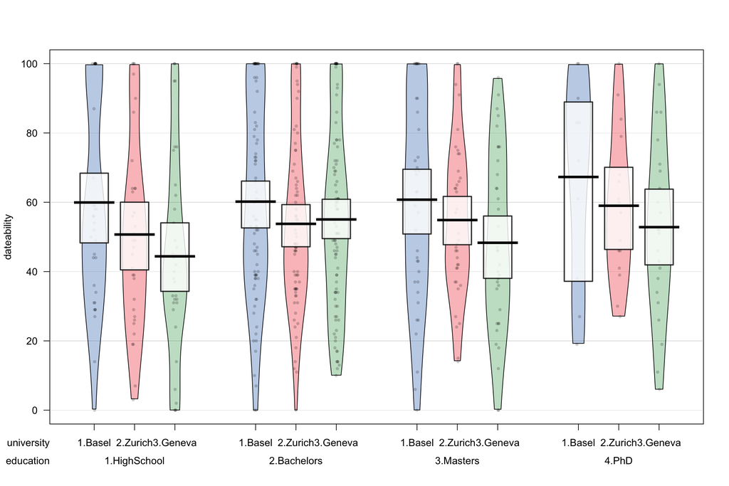

```r
pirateplot(dateability ~ university + education,
           data = facebook)
```

```r
# No there doesn't look like an interaction to me. The effect of university is the same in each level of education.
```

15. Test your prediction with the appropriate ANOVA. Report full APA style conclusions

```r
t15_aov <- aov(dateability ~ university * education,
               data = facebook)

summary(t15_aov)
```

```
##                       Df Sum Sq Mean Sq F value  Pr(>F)
## university             2   7602    3801   5.229 0.00566 **
## education              3   2335     778   1.071 0.36118
## university:education   6   2101     350   0.482 0.82215
## Residuals            488 354770     727
## ---
## Signif. codes:  0 '***' 0.001 '**' 0.01 '*' 0.05 '.' 0.1 ' ' 1
```

```r
# Yep! No significant interaction between university and education F(6, 488) = 0.48, p = 0.82.
```

16. Create a plot showing the distribution of dateability based on two independent variables: university and haircolor. Based on what you see in the plot, do you expect there to be an interaction between university and intelligence? Why or why not?

```r
pirateplot(dateability ~ university + haircolor,
           data = facebook)

# There does not look like an interaction
```

17. Test your prediction with the appropriate ANOVA. Report full APA style conclusions

```r
t17_aov <- aov(dateability ~ university * haircolor,
               data = facebook)

summary(t17_aov)
```

```
##                       Df Sum Sq Mean Sq F value  Pr(>F)
## university             2   7602    3801   5.242 0.00559 **
## haircolor              1    259     259   0.357 0.55070
## university:haircolor   2    719     359   0.496 0.60944
## Residuals            494 358228     725
## ---
## Signif. codes:  0 '***' 0.001 '**' 0.01 '*' 0.05 '.' 0.1 ' ' 1
```

```r
# Yep! no significant interaction! F(2, 494) = 0.49, p = 0.61
```

18. Repeat the test from the previous question, but **only** include males over the age of 25. Do you get the same answer?.

```r
t18_aov <- aov(dateability ~ university * haircolor,
               data = subset(facebook, sex == "m" & age > 25))

summary(t18_aov)
```

```
##                      Df Sum Sq Mean Sq F value Pr(>F)
## university            2    250   125.0   0.275  0.762
## haircolor             1   1139  1138.6   2.503  0.128
## university:haircolor  2   2487  1243.6   2.734  0.087 .
## Residuals            22  10007   454.9
## ---
## Signif. codes:  0 '***' 0.001 '**' 0.01 '*' 0.05 '.' 0.1 ' ' 1
```

```r
# Yep! Still no interaction, F(2, 22) = 2.73, p = .09
```